FJ

# Feidhelm Joyce

Business & Data Analyst  
Boston, MA

linkedin.com/in/feidhelmjoyce  
github.com/FeidhelmJ

FINANCIAL ANALYTICS

## Sovereign Risk & Bank Fragility

← Back to Financial Analytics

```
import numpy as np
import pandas as pd
import matplotlib.pyplot as plt
import seaborn as sns
```

# PART 0 – Conceptual Warm-Up (No Code)

Write 2–4 sentences:

A country has a low annual probability of default. Does that mean it is safe over long time horizons? Why or why not?

# PART 1 – Sovereign Risk Analysis (Dataset A)

## Step 1 – Load and Inspect

Load sovereign_risk_dataset.csv into Python

Display the dataset, being sure to show all rows and columns

Briefly describe the variables included here

```
pd.set_option('display.max_rows', None)
pd.set_option('display.max_columns', None)
```

```
risk = pd.read_csv('sovereign_risk_dataset.csv')
```

```
risk
```

|  | Country | Yield_i | RiskFree_i_star | Recovery_RR |
| --- | --- | --- | --- | --- |
| 0 | Greece | 0.090 | 0.030 | 0.35 |
| 1 | Italy | 0.060 | 0.030 | 0.45 |
| 2 | Argentina | 0.140 | 0.040 | 0.30 |
| 3 | Spain | 0.050 | 0.030 | 0.50 |
| 4 | Turkey | 0.110 | 0.040 | 0.40 |
| 5 | Brazil | 0.100 | 0.035 | 0.45 |
| 6 | Portugal | 0.055 | 0.030 | 0.50 |
| 7 | Mexico | 0.085 | 0.035 | 0.40 |

The dataset contains sovereign risk information for a set of countries. Yield_i represents the sovereign bond yield for each country, RiskFree_i_star is the corresponding risk-free benchmark rate, and Recovery_RR is the assumed recovery rate in the event of default. Together, these variables can be used to evaluate relative sovereign default risk.

## Step 2 – Compute Implied Default Probability

Create a new column called ‘PD’ to show the default probability for each country. Display your entire dataframe again now, showing that this new column has been included.

```
def compute_pd(yield_i, riskfree_i_star, recovery_rr):
    return (1 - (1 + riskfree_i_star) / (1 + yield_i)) / (1 - recovery_rr)
```

```
risk['PD'] = compute_pd(
    yield_i=risk['Yield_i'],
    riskfree_i_star=risk['RiskFree_i_star'],
    recovery_rr=risk['Recovery_RR'])
```

```
risk
```

|  | Country | Yield_i | RiskFree_i_star | Recovery_RR | PD |
| --- | --- | --- | --- | --- | --- |
| 0 | Greece | 0.090 | 0.030 | 0.35 | 0.084686 |
| 1 | Italy | 0.060 | 0.030 | 0.45 | 0.051458 |
| 2 | Argentina | 0.140 | 0.040 | 0.30 | 0.125313 |
| 3 | Spain | 0.050 | 0.030 | 0.50 | 0.038095 |
| 4 | Turkey | 0.110 | 0.040 | 0.40 | 0.105105 |
| 5 | Brazil | 0.100 | 0.035 | 0.45 | 0.107438 |
| 6 | Portugal | 0.055 | 0.030 | 0.50 | 0.047393 |
| 7 | Mexico | 0.085 | 0.035 | 0.40 | 0.076805 |

## Step 3 – Exploratory Data Analysis

You must include:

Generate a single histogram, showing all of the PD values in the dataframe.

A bar chart of PD by country. Order the bars, either from smallest to largest or largest to smallest.

For each graph, be sure that you have a descriptive title, along with descriptive axis labels.

```
plt.figure()
plt.hist(risk['PD'], bins=5)
plt.title('Distribution of Implied Default Probabilities (PD)')
plt.xlabel('Probability of Default (PD)')
plt.ylabel('Number of Countries')
plt.show()
```

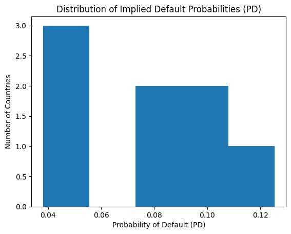

```
risk_sorted = risk.sort_values(by='PD', ascending=False)

plt.figure()
plt.bar(risk_sorted['Country'], risk_sorted['PD'])
plt.title('Implied Default Probability by Country')
plt.xlabel('Country')
plt.ylabel('Probability of Default (PD)')
plt.xticks(rotation=45)
plt.show()
```

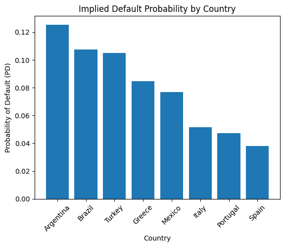

## Step 4 – Interpretation

Answer in one paragraph of approximately 120–180 words:

Which country appears most risky? Why?

Are PD values tightly clustered or widely spread?

Does yield alone explain PD? Or does recovery matter?

Argentina appears to be the most risky country, as it has the highest implied probability of default (PD). This is driven primarily by its very high sovereign yield relative to the risk-free rate, indicating that investors want a high premium to compensate for perceived default risk. The PD values are moderately spread rather than tightly clustered, with a clear gap between lower-risk European countries like Spain and Portugal and higher-risk emerging markets such as Argentina and Turkey. This suggests meaningful variation in perceived credit risk across countries. While yield plays a major role in explaining PD, since higher yields directly increase the spread over the risk-free rate, it does not fully determine it by itself. The recovery rate is also a factor, as higher recovery assumptions reduce the loss given default and therefore affect the implied probability. Countries with similar yields but different recovery rates can therefore have different PDs, highlighting that both market pricing and expected recovery are important in assessing sovereign risk.

# PART 1B – Interactive Sovereign Risk Explorer (ipywidgets)

You will now build a simple interactive tool to explore how sovereign default risk responds to changes in key variables.

Your widget must:

- include at least two sliders
- display at least two computed outputs
- update dynamically when inputs change

Objective

The formula for implied default probability depends on:

sovereign yield (i)

risk-free rate (i*)

recovery rate (RR)

Rather than evaluating a single fixed scenario, you will examine how changes in these inputs affect the output.

## Tasks

1. Using ipywidgets, create an interactive tool with sliders for:

Sovereign yield i (suggested range: 0.03 to 0.20)

Risk-free rate i* (suggested range: 0.01 to 0.08)

Recovery rate RR (suggested range: 0.20 to 0.70)

2. Your tool must display:

The selected input values

The computed implied default probability

```
import ipywidgets as widgets
from ipywidgets import interact
```

```
def sovereign_risk_explorer(yield_i=0.08, riskfree_i_star=0.03, recovery_rr=0.40):
    pd_value = compute_pd(yield_i, riskfree_i_star, recovery_rr)
    spread = yield_i - riskfree_i_star

    print(f"Sovereign Yield (i): {yield_i:.2%}")
    print(f"Risk-Free Rate (i*): {riskfree_i_star:.2%}")
    print(f"Recovery Rate (RR): {recovery_rr:.2%}")
    print(f"Yield Spread: {spread:.2%}")
    print(f"Implied Default Probability (PD): {pd_value:.2%}")

    plt.figure(figsize=(6,4))
    plt.bar(['Yield Spread', 'PD'], [spread, pd_value])
    plt.title('Sovereign Risk Explorer')
    plt.ylabel('Value')
    plt.ylim(0, max(spread, pd_value) + 0.05)
    plt.show()
```

```
interact(
    sovereign_risk_explorer,
    yield_i=widgets.FloatSlider(value=0.08, min=0.02, max=0.20, step=0.005, description='Yield (i)'),
    riskfree_i_star=widgets.FloatSlider(value=0.03, min=0.00, max=0.10, step=0.005, description='Risk-Free (i*)'),
    recovery_rr=widgets.FloatSlider(value=0.40, min=0.10, max=0.80, step=0.05, description='Recovery (RR)'));
```

INTERACTIVE · SOVEREIGN RISK EXPLORER

Yield (i) Risk-free (i*) Recovery (RR)

Yield spread Implied default probability

Yield spread

PD

Rebuilt for the web from the notebook's ipywidgets version, using the same formula and data.

## Exploration

Use your widget to test at least three different scenarios.

In a paragraph of 180-240 words, describe each of the three scenarios you examined. What did you notice with each one? Describe what you saw, and explain how these settings impact default probability.

I explored three different scenarios using the interactive tool to understand how changes in inputs affect implied default probability (PD). In the first scenario, I set a low-risk environment with a sovereign yield of 4%, a risk-free rate of 3%, and a recovery rate of 50%. This produced a very low PD, which makes sense because the yield spread is minimal, indicating that markets perceive little default risk. In the second scenario, I increased the yield to 12% while keeping the risk-free rate at 3% and recovery at 40%. This led to a significantly higher PD, showing how sensitive default probability is to increases in yield. The larger spread reflects greater perceived risk by investors. In the third scenario, I kept the yield high at 12% but increased the recovery rate to 60%. Interestingly, the PD increased further, highlighting that higher recovery rates reduce losses given default, which means a higher probability of default is needed to justify the same yield spread. Overall, I observed that yield has the strongest impact on PD, but recovery assumptions also play an important role in shaping the final probability.

## Interpretation Questions

Which variable appears to have the strongest effect on PD?

Does the relationship appear linear or nonlinear?

Did anything surprise you about how PD responds to changes?

Answer the questions shown above using 180-240 words. Be specific about the results that you saw.

Across the scenarios I tested, sovereign yield (i) clearly had the strongest effect on implied default probability (PD). Small increases in yield led to relatively large increases in PD, especially once the yield moved well above the risk-free rate. For example, increasing yield from around 6% to 12% (holding other variables constant) caused PD to rise sharply, reflecting how sensitive the model is to the yield spread. The risk-free rate had an effect in the opposite direction, with higher values reducing PD, but its impact was more gradual compared to changes in yield. Recovery rate also influenced PD, but in a more subtle and indirect way.

One surprising result was that higher recovery rates lead to higher implied PD, which is somewhat counterintuitive. Intuitively, higher recovery suggests less risk, but in this framework, it increases PD because investors expect to recover more in default, meaning a higher probability of default is needed to justify the same yield spread.

# PART 2 – Shock Scenario (Dataset A)

## Step 1 – Apply a Shock

Choose ONE:

Increase all yields by a fixed amount OR decrease all recovery rates

```
risk_shocked = risk.copy()

risk_shocked['Yield_i'] = risk_shocked['Yield_i'] + 0.04
```

## Step 2 – Recompute PD

Update your dataset, with newly calculated PD values based on the change you made above

```
risk_shocked['PD'] = compute_pd(
    yield_i=risk_shocked['Yield_i'],
    riskfree_i_star=risk_shocked['RiskFree_i_star'],
    recovery_rr=risk_shocked['Recovery_RR'])
```

```
risk_shocked
```

|  | Country | Yield_i | RiskFree_i_star | Recovery_RR | PD |
| --- | --- | --- | --- | --- | --- |
| 0 | Greece | 0.130 | 0.030 | 0.35 | 0.136147 |
| 1 | Italy | 0.100 | 0.030 | 0.45 | 0.115702 |
| 2 | Argentina | 0.180 | 0.040 | 0.30 | 0.169492 |
| 3 | Spain | 0.090 | 0.030 | 0.50 | 0.110092 |
| 4 | Turkey | 0.150 | 0.040 | 0.40 | 0.159420 |
| 5 | Brazil | 0.140 | 0.035 | 0.45 | 0.167464 |
| 6 | Portugal | 0.095 | 0.030 | 0.50 | 0.118721 |
| 7 | Mexico | 0.125 | 0.035 | 0.40 | 0.133333 |

## Step 3 – Visualization

Using any appropriate type of visualization, create a side-by-side comparison of your countries’ situation pre-shock and their situation post-shock

```
comparison = risk[['Country', 'PD']].merge(
    risk_shocked[['Country', 'PD']],
    on='Country',
    suffixes=('_original', '_shocked'))

comparison = comparison.sort_values(by='PD_original', ascending=False)

x = np.arange(len(comparison))
width = 0.35

plt.figure(figsize=(10,6))
plt.bar(x - width/2, comparison['PD_original'], width, label='Original PD')
plt.bar(x + width/2, comparison['PD_shocked'], width, label='Shocked PD')

plt.xticks(x, comparison['Country'], rotation=45)
plt.title('Pre-Shock vs Post-Shock Implied Default Probability by Country')
plt.xlabel('Country')
plt.ylabel('Probability of Default (PD)')
plt.legend()
plt.tight_layout()

plt.show()
```

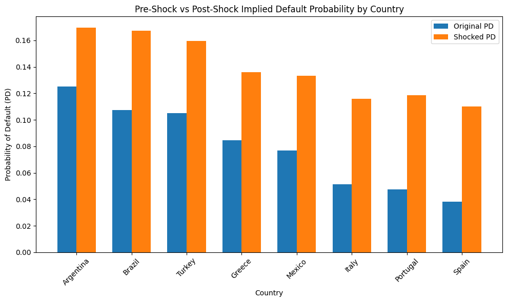

## Step 4 – Interpretation

Which country changed the most?

Did rankings change?

Did the system become more fragile overall?

# PART 3 – Portfolio Risk

## Step 1 – Compute System-Level Risk

Show the result.

```
def system_level_risk(pd_values):
    return 1 - np.prod(1 - pd_values)
```

```
portfolio_risk = system_level_risk(risk_shocked['PD'])
print(f"Probability that at least one country defaults: {portfolio_risk:.2%}")
```

```
Probability that at least one country defaults: 69.82%
```

## Step 2 – Sensitivity

Remove the riskiest country and recompute.

```
riskiest = risk_shocked.loc[risk_shocked['PD'].idxmax()]

print("Riskiest country removed:", riskiest['Country'])
```

```
Riskiest country removed: Argentina
```

```
risk_reduced = risk_shocked[risk_shocked['Country'] != riskiest['Country']]
```

```
reduced_portfolio_risk = system_level_risk(risk_reduced['PD'])

print(f"New system-level risk (without riskiest country): {reduced_portfolio_risk:.2%}")
```

```
New system-level risk (without riskiest country): 63.66%
```

## Step 3 – Interpretation

Answer these three questions using 180-240 words, total.

Why is the combined probability so high?

How much did removing one country matter?

Does diversification eliminate risk here?

The combined probability of at least one default is relatively high because the model aggregates risk across multiple countries, each with a non-zero probability of default. Even if individual PDs appear modest, combining them increases the likelihood that at least one event occurs. This effect is driven by the structure of the survival probabilities, when several countries each carry meaningful risk, the chance that all of them avoid default becomes quite low. As a result, the overall system-level risk rises quickly as more risky entities are included.

Removing the riskiest country had a noticeable impact, reducing the overall probability of at least one default. This highlights how much a single high-risk country can influence portfolio risk. However, the reduction was not dramatic enough to eliminate concern, as several other countries still contributed meaningful risk.

Diversification helps reduce exposure to any one country, but it does not eliminate risk in this case. Because default probabilities across countries are not negligible, the portfolio still carries substantial risk even after removing the most vulnerable country. This demonstrates that diversification can mitigate but not fully remove systemic risk, especially when underlying risks remain elevated across multiple entities.

# PART 4 – Bank Fragility

## Step 1 – Load and Inspect

Load bank_fragility_dataset.csv.

○ In this dataset:

- Assets and liabilities are measured in the billions
- Bond_portfolio refers to the portion of the bank’s assets invested in bonds (typically Treasuries or mortgage-backed securities)
- Uninsured_deposits refers to deposits that are above FDIC insurance limits (typically > $250K per account)

Display the dataset

```
bank = pd.read_csv('bank_fragility_dataset.csv')
```

```
bank
```

|  | Bank | Assets | Liabilities | Bond_Portfolio | Uninsured_Deposits |
| --- | --- | --- | --- | --- | --- |
| 0 | Bank_A | 100 | 92 | 40 | 60 |
| 1 | Bank_B | 120 | 108 | 50 | 70 |
| 2 | Bank_C | 80 | 70 | 25 | 40 |
| 3 | Bank_D | 150 | 135 | 70 | 90 |
| 4 | Bank_E | 90 | 82 | 30 | 55 |

## Step 2 – Compute Key Metrics

Create two new columns

● Equity = Assets – Liabilities

● Equity Ratio = Equity / Assets

```
bank['Equity'] = bank['Assets'] - bank['Liabilities']
bank['Equity_Ratio'] = bank['Equity'] / bank['Assets']
bank
```

|  | Bank | Assets | Liabilities | Bond_Portfolio | Uninsured_Deposits | Equity | Equity_Ratio |
| --- | --- | --- | --- | --- | --- | --- | --- |
| 0 | Bank_A | 100 | 92 | 40 | 60 | 8 | 0.080000 |
| 1 | Bank_B | 120 | 108 | 50 | 70 | 12 | 0.100000 |
| 2 | Bank_C | 80 | 70 | 25 | 40 | 10 | 0.125000 |
| 3 | Bank_D | 150 | 135 | 70 | 90 | 15 | 0.100000 |
| 4 | Bank_E | 90 | 82 | 30 | 55 | 8 | 0.088889 |

## Step 3 – Exploratory Data Analysis

Include:

● Display summary statistics of equity ratios for the banks.

● Generate a bar chart of equity ratios by bank. Be sure to include a descriptive title, and clear, descriptive labels for your axes.

● Summarize your results in a few sentences. What stands out here?

```
print(bank['Equity_Ratio'].describe())
```

```
count    5.000000
mean     0.098778
std      0.016889
min      0.080000
25%      0.088889
50%      0.100000
75%      0.100000
max      0.125000
Name: Equity_Ratio, dtype: float64
```

```
bank_sorted = bank.sort_values(by='Equity_Ratio', ascending=False)

plt.figure(figsize=(8,5))
plt.bar(bank_sorted['Bank'], bank_sorted['Equity_Ratio'])

plt.title('Equity Ratios by Bank')
plt.xlabel('Bank')
plt.ylabel('Equity Ratio')
plt.xticks(rotation=45)

plt.tight_layout()
plt.show()
```

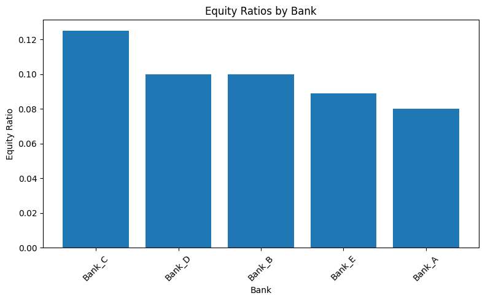

The equity ratios show some clear differences across the banks. Bank_C stands out as the strongest, with the highest ratio at around 12.5%, which suggests it has the largest buffer to absorb losses. Bank_D and Bank_B sit in the middle at about 10%, so they look reasonably well-capitalized but not particularly strong. Bank_E is slightly lower, just under 9%, while Bank_A is the weakest at around 8%. That’s important because a lower equity ratio means less protection if things go wrong. Overall, the banks aren’t wildly different, but there is a noticeable gap between the strongest and weakest. Bank_A in particular looks more vulnerable compared to the others, while Bank_C appears to be in the best position if a shock were to hit.

## Step 4 – Apply Your Shock

Choose ONE shock:

2. Bond Loss Shock

○ Select a percentage (e.g., 15%)

○ Reduce each bank’s Bond_Portfolio by that percentage

○ Subtract the loss from total assets

Clearly state your chosen percentage and show the updated values.

```
shock_pct = 0.15
bank_shocked = bank.copy()
```

```
bank_shocked['Bond_Loss'] = bank_shocked['Bond_Portfolio'] * shock_pct
```

```
bank_shocked['Assets'] = bank_shocked['Assets'] - bank_shocked['Bond_Loss']
```

```
bank_shocked['Equity'] = bank_shocked['Assets'] - bank_shocked['Liabilities']
bank_shocked['Equity_Ratio'] = bank_shocked['Equity'] / bank_shocked['Assets']
```

```
print(bank_shocked[['Bank', 'Bond_Portfolio', 'Bond_Loss', 'Assets', 'Equity', 'Equity_Ratio']])
```

```
     Bank  Bond_Portfolio  Bond_Loss  Assets  Equity  Equity_Ratio
0  Bank_A              40       6.00   94.00    2.00      0.021277
1  Bank_B              50       7.50  112.50    4.50      0.040000
2  Bank_C              25       3.75   76.25    6.25      0.081967
3  Bank_D              70      10.50  139.50    4.50      0.032258
4  Bank_E              30       4.50   85.50    3.50      0.040936
```

## Step 5 – Recompute Financial Position

Update:

● Assets - Already updated above.

● Equity

● Solvency status

```
bank_shocked['Equity'] = bank_shocked['Assets'] - bank_shocked['Liabilities']
```

```
bank_shocked['Solvency_Status'] = bank_shocked['Equity'].apply(
    lambda x: 'Solvent' if x > 0 else 'Insolvent')
```

```
print(bank_shocked[['Bank', 'Assets', 'Liabilities', 'Equity', 'Equity_Ratio', 'Solvency_Status']])
```

```
     Bank  Assets  Liabilities  Equity  Equity_Ratio Solvency_Status
0  Bank_A   94.00           92    2.00      0.021277         Solvent
1  Bank_B  112.50          108    4.50      0.040000         Solvent
2  Bank_C   76.25           70    6.25      0.081967         Solvent
3  Bank_D  139.50          135    4.50      0.032258         Solvent
4  Bank_E   85.50           82    3.50      0.040936         Solvent
```

## Step 6 – Visualization

Include:

● Before vs after equity comparison

A bank is considered to have failed if its equity becomes negative after applying the shock.

```
comparison = bank[['Bank', 'Equity']].merge(
    bank_shocked[['Bank', 'Equity']],
    on='Bank',
    suffixes=('_original', '_shocked'))

comparison = comparison.sort_values(by='Equity_original', ascending=False)
```

```
x = np.arange(len(comparison))
width = 0.35

plt.figure(figsize=(10,6))
plt.bar(x - width/2, comparison['Equity_original'], width, label='Original Equity')
plt.bar(x + width/2, comparison['Equity_shocked'], width, label='Post-Shock Equity')

plt.xticks(x, comparison['Bank'], rotation=45)
plt.title('Before vs After Equity by Bank')
plt.xlabel('Bank')
plt.ylabel('Equity')
plt.legend()

plt.tight_layout()
plt.show()
```

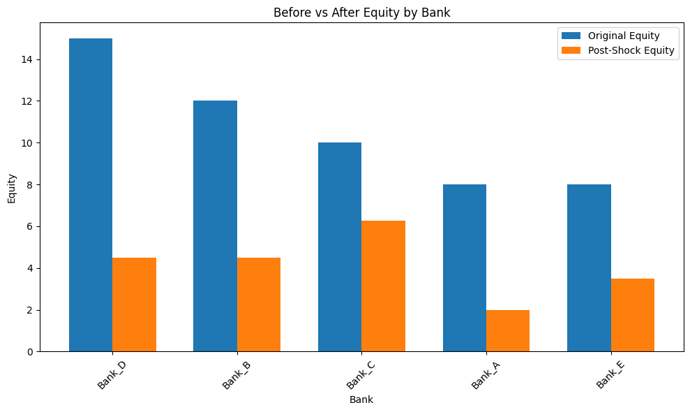

## Step 7 – Interpretation

● Which bank failed first (if any)?

● What variable mattered most?

● Did size help or hurt stability?

No bank actually failed in this scenario, as all banks still have positive equity after the shock. However, Bank_A comes closest to failure, with its equity dropping to around 2, making it the most vulnerable.

The variable that mattered most here was the size of each bank’s bond portfolio, since the shock directly reduced that asset. Banks with larger exposure to bonds experienced bigger absolute losses, which translated into larger drops in equity. You can see this clearly with Bank_D and Bank_B, which had large initial equity but also large declines.

In terms of size, it’s a bit of a mixed result. Larger banks started with more equity, which helped absorb the shock, but they also had larger bond portfolios, which meant bigger losses. So size provided a buffer, but also increased exposure to the shock. Overall, stability depended more on the composition of assets rather than just the size of the bank, with bond exposure playing the biggest role in determining how much each bank was affected.

## PART 4B – Interactive Bank Stress Test (ipywidgets)

You will now build an interactive tool to explore how banks respond to financial stress.

Objective

In Part 4, you applied a single shock to a bank balance sheet. Now, you will explore how different levels of stress affect:

● assets

● equity

● solvency

Your widget must:

● include at least two sliders

● display at least two computed outputs

● update dynamically when inputs change

```
import ipywidgets as widgets
from ipywidgets import interact
```

```
def bank_stress_test(selected_bank, bond_decline_pct=0.15, deposit_withdrawal_pct=0.20):
    # pull the selected bank's row
    row = bank[bank['Bank'] == selected_bank].iloc[0]

    assets = row['Assets']
    liabilities = row['Liabilities']
    bond_portfolio = row['Bond_Portfolio']
    deposits = row['Uninsured_Deposits']

    bond_loss = bond_portfolio * bond_decline_pct
    deposit_outflow = deposits * deposit_withdrawal_pct

    updated_assets = assets - bond_loss - deposit_outflow
    updated_equity = updated_assets - liabilities

    solvency = "Solvent" if updated_equity > 0 else "Insolvent"

    print(f"Bank: {selected_bank}")
    print(f"Bond Portfolio Decline: {bond_decline_pct:.0%}")
    print(f"Deposit Withdrawal: {deposit_withdrawal_pct:.0%}")
    print(f"Updated Assets: {updated_assets:.2f}")
    print(f"Updated Equity: {updated_equity:.2f}")
    print(f"Solvency Status: {solvency}")
    plt.figure(figsize=(6,4))
    plt.bar(['Updated Assets', 'Updated Equity'], [updated_assets, updated_equity])
    plt.title(f'Bank Stress Test: {selected_bank}')
    plt.ylabel('Value')
    plt.show()

interact(
    bank_stress_test,
    selected_bank=widgets.Dropdown(
        options=bank['Bank'].tolist(),
        value=bank['Bank'].iloc[0],
        description='Bank'
    ),
    bond_decline_pct=widgets.FloatSlider(
        value=0.15, min=0.00, max=0.30, step=0.01, description='Bond Loss'
    ),
    deposit_withdrawal_pct=widgets.FloatSlider(
        value=0.20, min=0.00, max=0.50, step=0.01, description='Deposit Run'
    )
);
```

INTERACTIVE · BANK STRESS TEST

Bank Bond loss Deposit run

Updated assets Updated equity Solvency status

Updated assets

Updated equity

Rebuilt for the web from the notebook's ipywidgets version, using the same formula and data.

Tasks

1. Using ipywidgets, create an interactive tool with sliders for:

○ Bond portfolio decline (%) (suggested range: 0% to 30%)

○ Deposit withdrawal (%) (suggested range: 0% to 50%)

2. Your tool must display:

○ Updated asset value

○ Updated equity

○ A clear indication of whether the bank is solvent

Required Exploration:

Test at least three different combinations of shocks.

In a paragraph of 180-240 words, describe each of the three shock scenarios that you examined. What did you notice with each one? Describe what you saw, and explain how these settings impact bank solvency.

I tested three different stress scenarios on Bank_A using the interactive tool. In the first scenario, I applied a 25% deposit withdrawal with no bond losses. This alone was enough to push the bank into insolvency, with equity falling to -7. This shows how sensitive the bank is to deposit runs, even without asset-side shocks. In the second scenario, I combined a 30% bond portfolio decline with a 25% deposit withdrawal. This had a much more severe impact, reducing assets further and driving equity down to -19, making the bank deeply insolvent. This highlights how dangerous it is when both market losses and funding pressure occur at the same time. In the third scenario, I tested a milder shock with a 10% deposit withdrawal and no bond losses. In this case, the bank remained solvent, with equity still positive at around 2, although significantly reduced. Overall, what stands out is how quickly solvency deteriorates as shocks increase. Deposit withdrawals had a major impact, and when combined with bond losses, they amplified the stress significantly. The results show that even moderately sized shocks can threaten stability if the bank starts with limited capital.

Interpretation Questions

● Which type of shock appears more dangerous: bond losses or withdrawals?

● At what point does the bank become insolvent?

● Does failure occur gradually or suddenly?

Answer the above questions using 180-240 words. Your interpretation should reference specific findings. Mention impacts that occurred at particular values.

Based on the scenarios tested, deposit withdrawals appear more dangerous than bond losses for Bank_A. A 25% deposit withdrawal alone (with no bond losses) was enough to push the bank into insolvency, with equity falling to -7. In contrast, bond losses only became severely damaging when combined with withdrawals. For example, a 30% bond decline alongside a 25% withdrawal led to a much deeper insolvency (equity of -19), but the key trigger was already present from the withdrawal side. This suggests that liquidity shocks (runs) have a more immediate and severe impact than asset price declines on their own.

Failure appears to occur suddenly rather than gradually. The bank transitions from being solvent to insolvent over a relatively small increase in stress (from 10% to 25% withdrawal). This sharp tipping point highlights how fragile the balance sheet is, where modest increases in stress can quickly push equity below zero and trigger failure.

## PART 5 – Your Custom Shock

Introduce one additional change of your choosing. Examples:

● Combine shocks

● Target one bank more than others

● Increase severity

Tasks

● Recompute outcomes

```
bank_custom = bank.copy()

bond_decline = 0.15
bank_custom['Bond_Loss'] = bank_custom['Bond_Portfolio'] * bond_decline

bank_custom['Deposit_Run'] = bank_custom['Uninsured_Deposits'] * 0.20

# Target Bank_A with a more severe deposit run
bank_custom.loc[bank_custom['Bank'] == 'Bank_A', 'Deposit_Run'] = (
    bank_custom.loc[bank_custom['Bank'] == 'Bank_A', 'Uninsured_Deposits'] * 0.35)

bank_custom['Assets'] = bank_custom['Assets'] - bank_custom['Bond_Loss'] - bank_custom['Deposit_Run']

bank_custom['Equity'] = bank_custom['Assets'] - bank_custom['Liabilities']

bank_custom['Equity_Ratio'] = bank_custom['Equity'] / bank_custom['Assets']

bank_custom['Solvency_Status'] = bank_custom['Equity'].apply(
    lambda x: 'Solvent' if x > 0 else 'Insolvent')

print(bank_custom[['Bank', 'Assets', 'Liabilities', 'Equity', 'Equity_Ratio', 'Solvency_Status']])
```

```
     Bank  Assets  Liabilities  Equity  Equity_Ratio Solvency_Status
0  Bank_A   73.00           92  -19.00     -0.260274       Insolvent
1  Bank_B   98.50          108   -9.50     -0.096447       Insolvent
2  Bank_C   68.25           70   -1.75     -0.025641       Insolvent
3  Bank_D  121.50          135  -13.50     -0.111111       Insolvent
4  Bank_E   74.50           82   -7.50     -0.100671       Insolvent
```

Interpretation

● Did outcomes change dramatically?

● Was the system stable or fragile?

● Did a small change produce a large effect?

# FINAL SECTION – Reflection

Write a short response:

Which system appears more fragile: the sovereign system or the banking system?

Support your answer using your results. Reference specific findings. Answer this in approximately 180-240 words.

Overall, the banking system appears more fragile than the sovereign system based on the results observed. In the sovereign analysis, even after applying a uniform yield shock, default probabilities increased across all countries, but the system did not collapse entirely. The rankings remained largely unchanged, and while risk rose, it did so in a more gradual and predictable way. This suggests that sovereign risk, while sensitive to market conditions, is somewhat more stable and dispersed across countries.

In contrast, the banking system showed much sharper responses to stress. Even moderate shocks, such as a 25% deposit withdrawal, were enough to push Bank_A into insolvency. More importantly, when combining shocks in the custom scenario, all banks became insolvent, with equity turning negative across the entire system. This indicates that the banking system is highly sensitive to both asset losses and liquidity shocks, and that risks can compound quickly. The tipping point behavior—where solvency shifts rapidly from positive to negative—highlights a lack of resilience.

Overall, while both systems exhibit increased risk under stress, the banking system demonstrates greater fragility due to its sensitivity to withdrawals and the speed at which losses can erode capital.